# Machine Learning - Final Project

Aviv Zach

Thursday, August 20, 2015

### Abstract

This paper describes the steps that were taken in order to build the model for the final project in the Machhine Learning course.

Data was driven from the Human Activity Recognition web site. The data contain physical information that was collected from 6 diffrent subjects as they were performing barbell lifts correctly and incorrectly in 5 different ways.

The following model predicts in what way the participants preforme barbell lifts.

### Loading the data

```r
#url<-"https://d396qusza40orc.cloudfront.net/predmachlearn/pml-training.csv"
#download.file(url,"trainData.csv")
library(caret)
unclean_dt<-read.csv("trainData.csv")
```

### Cleaning the data of irrelevant variabels

First I cleaned variabels that consists summary statistics on the data (max/min/mean,etc.)

```r
unnescry_stat<-grep("max|min|avg|stddev|var|amplitude|total|kurtosis|skewness",names(unclean_dt))
```

Then erase irrelevent meta data

```r
meta_data<-c(1:7)
remove<-c(unnescry_stat,meta_data)
trndt<-unclean_dt[,-remove]
```

### Removing corrlated variabels

```r
rm_cor<-findCorrelation(cor(trndt[-49]))
trndt<-trndt[,-rm_cor]
```

# Partitioning the Data

I partitioned the data to a training set and a test set:

```r
traininx<-createDataPartition(y = trndt$classe,p = 0.7,list = FALSE)
train<-trndt[traininx,]
test <-trndt[-traininx,]
```

# Which Variabels should I use?:

I used ANOVA in order to check which variabels were correlated with the classe( the way that the subject performed barbell lifts ).

```r
colums<-vector()
for ( i in 1:42){
        p<-summary(aov(train[,i]~train[,43]))[[1]][["Pr(>F)"]][1]
        if (p<0.05) {
                colums<-c(colums,i)
        }
}
new_train<-train[,c(colums,43)]
```

Next I used only the variabells that were significantly correlated with classe.

The variabels that I used are:

```r
names(train)[colums]
```

```
##  [1] "pitch_belt"        "yaw_belt"          "gyros_belt_x"
##  [4] "gyros_belt_z"      "accel_belt_y"      "magnet_belt_x"
##  [7] "magnet_belt_y"     "magnet_belt_z"     "roll_arm"
## [10] "pitch_arm"         "yaw_arm"           "gyros_arm_y"
## [13] "accel_arm_x"       "accel_arm_y"       "accel_arm_z"
## [16] "magnet_arm_x"      "magnet_arm_y"      "magnet_arm_z"
## [19] "roll_dumbbell"     "pitch_dumbbell"    "yaw_dumbbell"
## [22] "gyros_dumbbell_y"  "accel_dumbbell_x"  "accel_dumbbell_y"
## [25] "accel_dumbbell_z"  "magnet_dumbbell_x" "magnet_dumbbell_y"
## [28] "magnet_dumbbell_z" "roll_forearm"      "pitch_forearm"
## [31] "yaw_forearm"       "gyros_forearm_x"   "accel_forearm_x"
## [34] "accel_forearm_y"   "accel_forearm_z"   "magnet_forearm_x"
## [37] "magnet_forearm_y"  "magnet_forearm_z"
```

# Model Building

I built the model using boosting with trees method, and used a 10-fold cross validation.

```r
t_c<- trainControl(method="repeatedcv", number=10,)
mdl<- train(new_train$classe~., data=new_train, trControl=t_c, method="gbm",verbose=FALSE)
```

# Testing the model

Itested the model on the test part of the dataset to get a 0.95 accuracy

```r
new_test<-test[,c(colums,43)]
pre<-predict(mdl,new_test)
confusionMatrix(new_test[,39],pre)
```

```
## Confusion Matrix and Statistics
##
##           Reference
## Prediction    A    B    C    D    E
##          A 1640   28    3    2    1
##          B   29 1069   35    4    2
##          C    0   36  975   11    4
##          D    3    2   48  907    4
##          E    2   14   12   15 1039
##
## Overall Statistics
##
##                Accuracy : 0.9567
##                  95% CI : (0.9512, 0.9617)
##     No Information Rate : 0.2845
##     P-Value [Acc > NIR] : < 2.2e-16
##
##                   Kappa : 0.9452
##  Mcnemar's Test P-Value : 1.025e-06
##
## Statistics by Class:
##
##                      Class: A Class: B Class: C Class: D Class: E
## Sensitivity            0.9797   0.9304   0.9087   0.9659   0.9895
## Specificity            0.9919   0.9852   0.9894   0.9885   0.9911
## Pos Pred Value         0.9797   0.9385   0.9503   0.9409   0.9603
## Neg Pred Value         0.9919   0.9831   0.9798   0.9935   0.9977
## Prevalence             0.2845   0.1952   0.1823   0.1596   0.1784
## Detection Rate         0.2787   0.1816   0.1657   0.1541   0.1766
## Detection Prevalence   0.2845   0.1935   0.1743   0.1638   0.1839
## Balanced Accuracy      0.9858   0.9578   0.9490   0.9772   0.9903
```

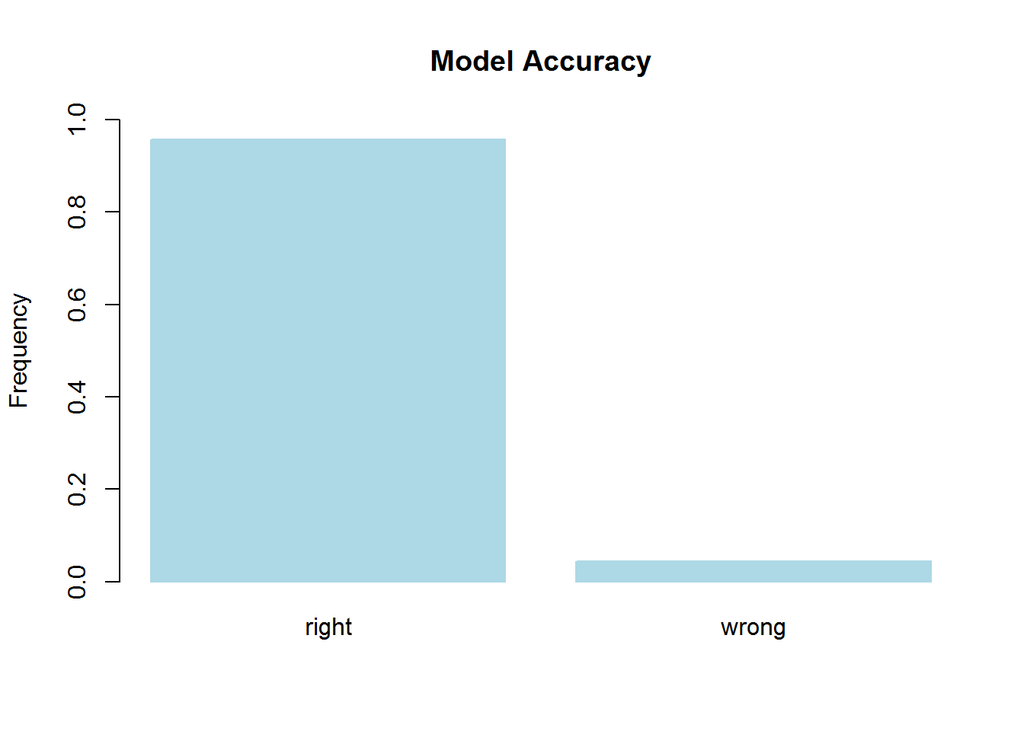